# L04 Exploratory Data Analysis

### Exercise 10

Recreate the horizontal boxplot below without using `coord_flip()`.

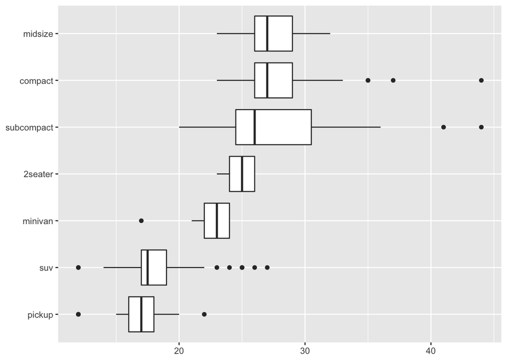

```r
ggplot(data = mpg) +
  geom_boxplot(mapping = aes(x = reorder(class, hwy, FUN = median), y = hwy)) +
  labs(
    x = NULL,
    y = NULL
  ) +
  coord_flip()
```

### Exercise 11

One problem with boxplots is that they were developed in an era of much smaller datasets and tend to display a prohibitively large number of “outlying values.” One approach to remedy this problem is the letter value plot. Install the `lvplot` package and try using `geom_lv()` to display the distribution of `price` vs `cut`. What do you learn? How do you interpret the plots? [Check out this paper](http://vita.had.co.nz/papers/letter-value-plot.pdf)

### Exercise 12

Display the relationship between `price` and `cut` using `geom_violin()` and again using a faceted version of `geom_histogram()`. What are the pros and cons of each method?

### Exercise 13

Can you rescale the data used in the plot below to more clearly show the distribution of cut within color, or color within cut? Starting from the code below, use rescaling to show the distribution of (a) cut within color and (b) color within cut.

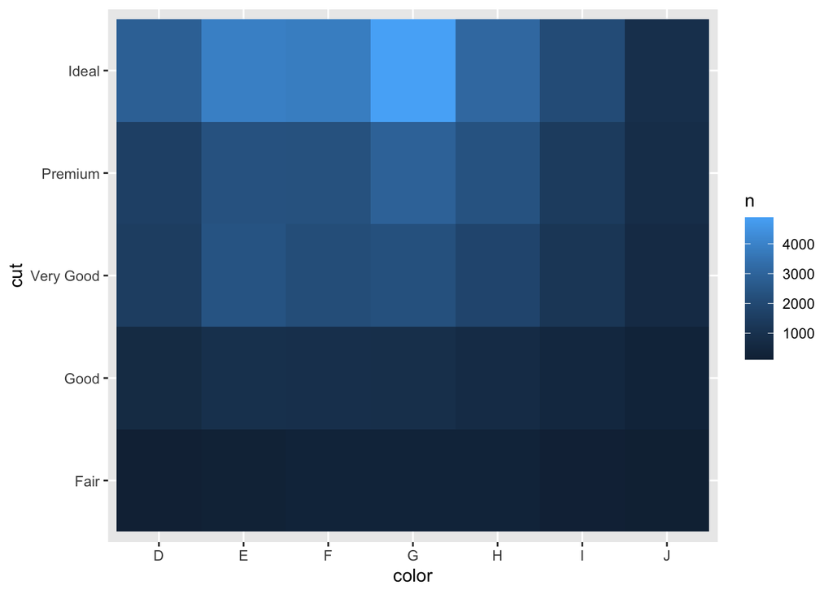

```r
diamonds %>%
  count(color, cut) %>%
  ggplot(mapping = aes(x = color, y = cut)) +
    geom_tile(mapping = aes(fill = n))
```

### Exercise 14

In Exercise 13, why is it slightly better to use `aes(x = color, y = cut)` instead of `aes(x = cut, y = color)`?

### Exercise 15

Use `geom_tile()` together with `dplyr` to explore how average flight delays vary by destination and month of year. What makes the plot hard to read? Improve the plot.

### Exercise 16

Use the `smaller` dataset defined below for this exercise. Visualize the distribution of `carat` broken down by `price`. Construct 2 graphics, one using `cut_width()` and the other using `cut_number()`.

```r
smaller <- diamonds %>%
  filter(carat < 3)
```

### Exercise 17

How does the distribution of `price` differ for very large diamonds (`carat` $\ge$ 3)? Is this result surprising? Why or why not?

### Exercise 18

Combine two of the techniques you’ve learned to visualize the combined distribution of `cut`, `carat`, and `price`.